# Take home Exercise 5 - due 20 Feb 2359

Putting Visual Analytics into Practical Use

Frostbear https://sg.linkedin.com/in/farahfoo (SMU Masters in IT business (Fintech and Analytics))https://scis.smu.edu.sg/master-it-business  
2022-02-20

# Task

Create a data visualisation to segment kid drinks and other by nutrition indicators. For the purpose of this task, starbucks_drink.csv should be used.

# Installing and Launching R Packages

```r
packages = c('corrplot', 'tidyverse', 'ggstatsplot', 'ggplot2', 'ggcorrplot', 'GGally', 'parcoords')

for(p in packages){
  if(!require(p, character.only = T)){
    install.packages(p)
  }
  library(p, character.only = T)
}
```

## Importing Data

The data set consist of 18 variables and 2068 observations, of starbucks drinks and its contents.

```r
starbucks <- read_csv("data/starbucks_drink.csv")

head (starbucks, 3)
```

```
# A tibble: 3 x 18
  Category    Name          `Portion(fl oz)` Calories `Calories from ~
  <chr>       <chr>                    <dbl>    <dbl>            <dbl>
1 iced-coffee Cold Brew wi~               12       50                0
2 iced-coffee Cold Brew wi~               16       80                0
3 iced-coffee Cold Brew wi~               24      100                0
# ... with 13 more variables: Total Fat(g) <dbl>,
#   Saturated fat(g) <dbl>, Trans fat(g) <dbl>,
#   Cholesterol(mg) <dbl>, Sodium(mg) <dbl>,
#   Total Carbohydrate(g) <dbl>, Dietary Fiber(g) <dbl>,
#   Sugars(g) <dbl>, Protein(g) <dbl>, Caffeine(mg) <chr>,
#   Size <chr>, Milk <chr>, Whipped Cream <chr>
```

## Correlation Matrix

Plotting a correlation matrix for all the drinks in the data set

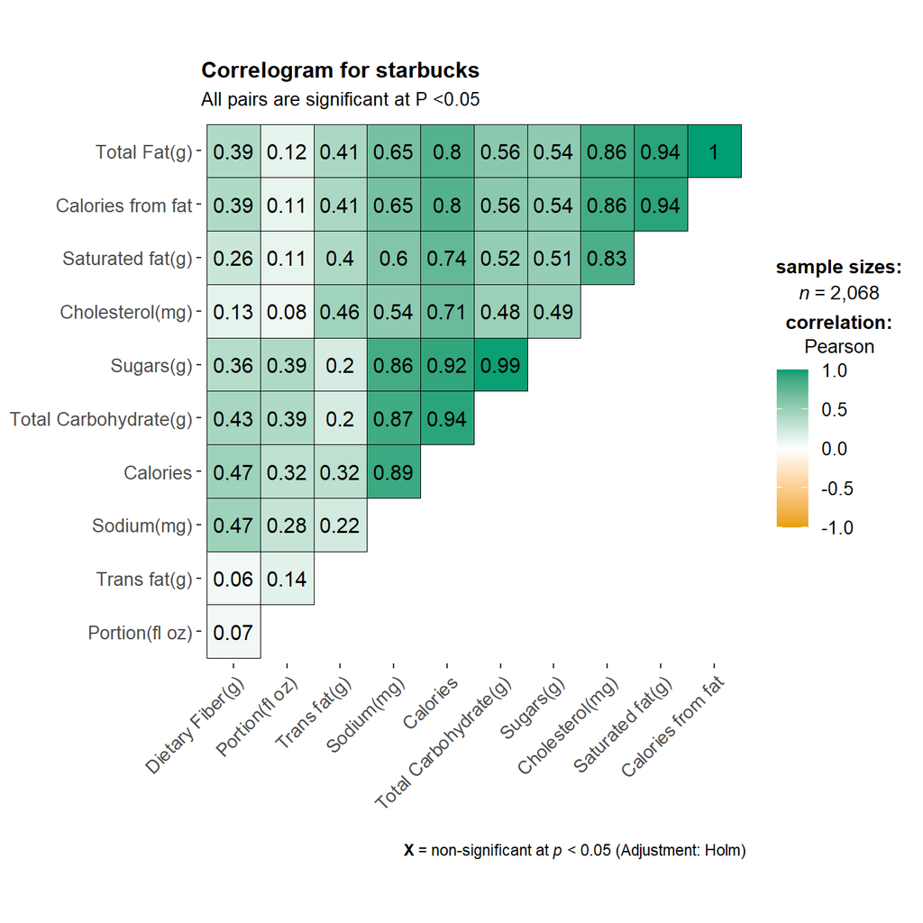

```r
ggstatsplot::ggcorrmat(
  data = starbucks,
  cor.vars = 1:13,
  ggcorrplot.args = list(outline.color = "black",
                        hc.order = TRUE ,
                        tl.cex = 10 ) ,
title = "Correlogram for starbucks",
subtitle = "All pairs are significant at P <0.05")
```

Plotting correlation matrix for the category “kids drinks and other”

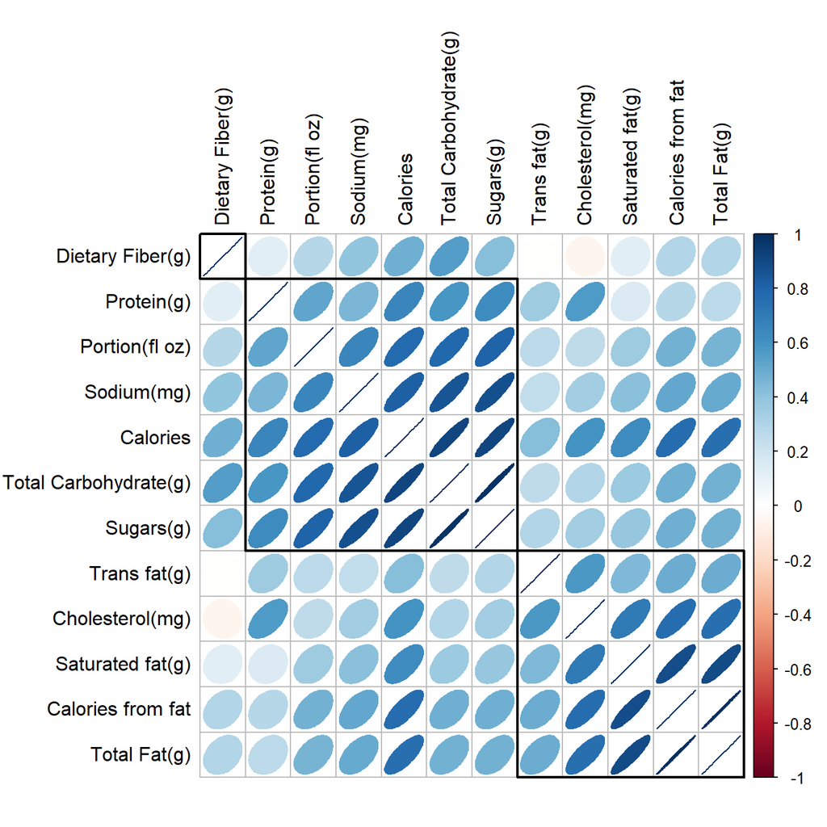

```r
starbucks.kids <- starbucks %>%
  filter(Category == "kids-drinks-and-other") %>%
  select(c(3:14))

starbucks.cor<-cor(starbucks.kids)


corrplot (starbucks.cor, method = "ellipse",
          tl.pos = "lt" ,
          tl.col = "black" ,
          order= "hclust" ,
          hclust.method = "complete" ,
          addrect = 3 )
```

Showing the correlation table in a mixed layout format,

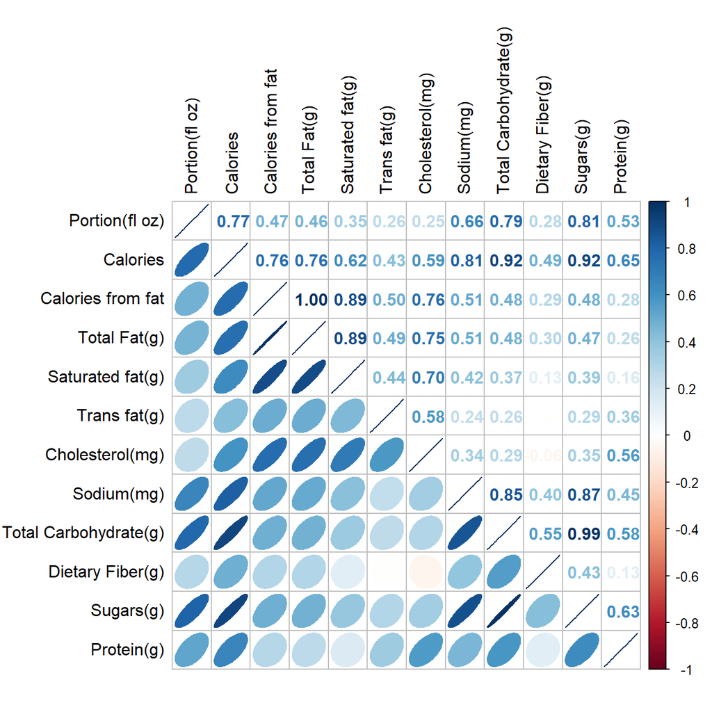

```r
corrplot.mixed( starbucks.cor, lower = "ellipse",
                upper = "number" ,
                tl.pos = "lt" ,
                diag = "l" ,
                tl.col = "black" )
```

Performing the correlation test to see which pair of variables are statistically significant, the below combines the corrgram with the significant test.

Figure reveals that not all correlation pairs are statistically significant. * the correlation between the portion and calories, sodium, sugar and total carbo is statistically significant at significant level 0.05 * but not for Cholesterol total fat.

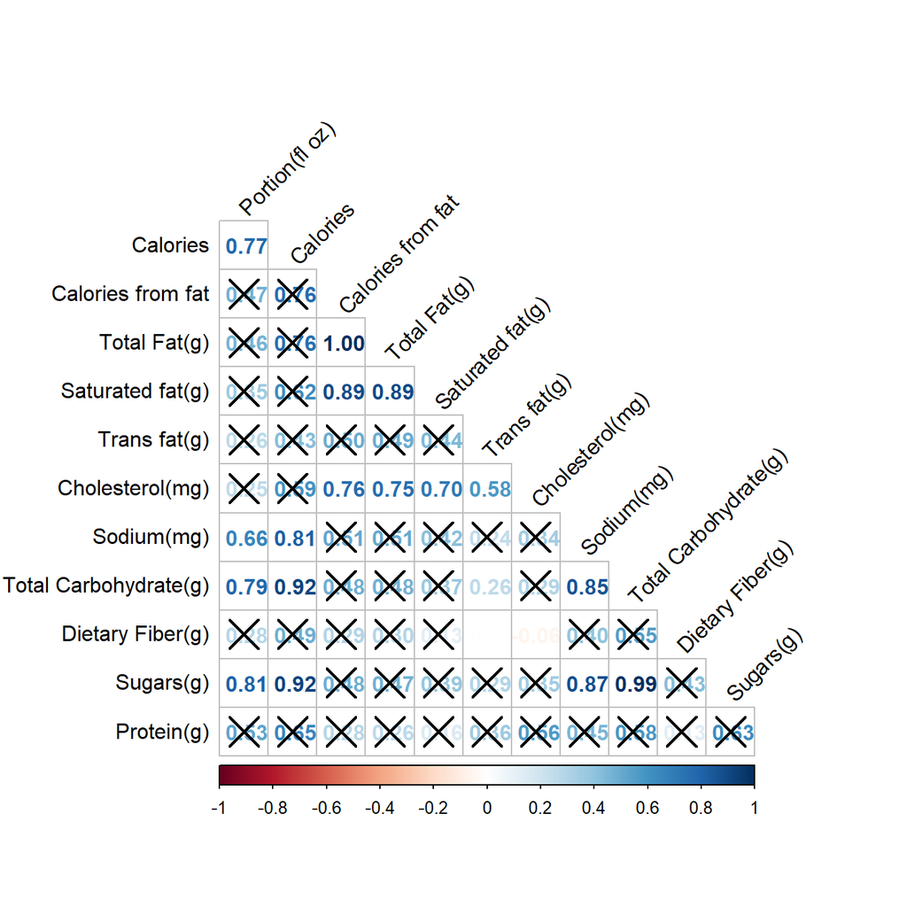

```r
starbucks.sig = cor.mtest( starbucks.cor , conf.level= .95 )

corrplot ( starbucks.cor ,
            method = "number" ,
            type = "lower" ,
            diag = FALSE ,
            tl.col = "black" ,
            tl.srt = 45 ,
            p.mat = starbucks.sig $ p ,
            sig.level = .05 )
```

```r
starbucks.kids1 <- starbucks %>%
  filter(Category == "kids-drinks-and-other")
```

There are 5 sizes of the drinks.

```r
unique(starbucks.kids1$Size)
```

```
[1] "Tall"   "Grande" "Venti"  "Kids"   "Short"
```

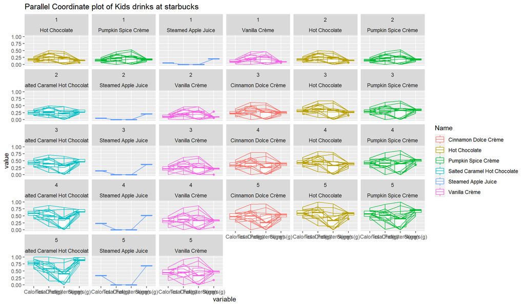

```r
starbucks.kids1  <- starbucks.kids1 %>%
  mutate (sizelevel = case_when (Size == 'Tall' ~ 3,
                                 Size == 'Grande' ~ 4,
                                 Size == 'Venti' ~ 5,
                                 Size == 'Kids' ~ 1,
                                 Size == 'Short' ~ 2))

ggparcoord( data = starbucks.kids1 ,
columns = c ( 4,6,9,13 ),
groupColumn = 2 ,
scale = "uniminmax",
boxplot = TRUE ,
title = "Parallel Coordinate plot of Kids drinks at starbucks") +
facet_wrap( sizelevel ~ Name )
```

From the chart, it is clear that Total Fat and Cholesterol is negligible in Steamed Apple Juice. The salted caramel hot chocolate drink has the highest amount of sugar and calories compared to other drinks of the Venti size.

## Plotting an Interactive Parallel Coordinates Plot

Highlight over the range to see the selection activated

```r
unique(starbucks.kids1$Name)
```

```
[1] "Cinnamon Dolce Crème"         "Hot Chocolate"
[3] "Pumpkin Spice Crème"          "Salted Caramel Hot Chocolate"
[5] "Steamed Apple Juice"          "Vanilla Crème"
```

```r
hotchocolate <- starbucks.kids1 %>%
  filter (Name == 'Hot Chocolate')

steamedapplejuice <- starbucks.kids1 %>%
  filter (Name == 'Steamed Apple Juice')
```

```r
parcoords((hotchocolate [ , c(3,4,6,9,13)]),
rownames = FALSE ,
alpha = 0.3 ,
alphaOnBrushed = 0.2 ,
reorderable = T ,
brushMode = '1D-axes' ,
width = 700 ,
height = 400 )
```

[interactive chart not shown]

```r
parcoords((steamedapplejuice [ , c(3,4,6,9,13)]),
rownames = FALSE ,
alpha = 0.3 ,
alphaOnBrushed = 0.2 ,
reorderable = T ,
brushMode = '1D-axes' ,
width = 700 ,
height = 400 )
```

[interactive chart not shown]